# 📊 IntelliExtract AI - Exploratory Data Analysis

**Multi-Modal Invoice Field Extraction System**

## Executive Summary

This notebook performs comprehensive EDA on invoice extraction results from the IntelliExtract AI system, which combines:

- **OCR** (EasyOCR + Tesseract) - Text extraction
- **YOLO** (YOLOv8) - Signature/stamp detection
- **Vision LLM** (llama3.2-vision) - Contextual field mapping

### Analysis Coverage

1. **State-wise Distribution** - Geographic analysis of dealer locations
2. **Language Analysis** - English vs Hindi/Mixed language invoices
3. **Processing Time Analysis** - Performance metrics and bottlenecks
4. **Confidence Analysis** - Extraction quality assessment
5. **Error Correlation** - Language type vs error rate
6. **Field-wise Performance** - Individual field extraction accuracy

**Dataset:** Invoice extraction results (JSON format)  
**Date:** January 22, 2026  
**System:** IntelliExtract AI v1.0

## 1. Import Required Libraries

```python
# Data manipulation and analysis
import json
import pandas as pd
import numpy as np
from pathlib import Path
from collections import Counter, defaultdict
import re

# Visualization libraries
import matplotlib.pyplot as plt
import seaborn as sns
import warnings

# Configure plotting
plt.style.use('seaborn-v0_8-darkgrid')
sns.set_palette("husl")
plt.rcParams['figure.figsize'] = (14, 8)
plt.rcParams['font.size'] = 11
warnings.filterwarnings('ignore')

# Display settings
pd.set_option('display.max_columns', None)
pd.set_option('display.max_rows', 100)
pd.set_option('display.float_format', '{:.2f}'.format)

print("✓ Libraries imported successfully")
```

```
✓ Libraries imported successfully
```

## 2. Load and Inspect Dataset

Load invoice extraction results from JSON file or generate sample data for demonstration.

```python
# Function to generate sample data if no results file available
def generate_sample_data(n=100):
    """Generate sample invoice extraction results"""
    states = ['PUNJAB', 'HARYANA', 'UTTAR PRADESH', 'MAHARASHTRA', 'RAJASTHAN',
              'MADHYA PRADESH', 'GUJARAT', 'KARNATAKA', 'TAMIL NADU']
    models = ['TAFE MF 241', 'Mahindra 575 DI', 'SONALIKA DI 35 RX', 'John Deere 5050D',
              'New Holland 3630 TX', 'Escorts Powertrac 439']

    results = []
    for i in range(n):
        state = np.random.choice(states)
        model = np.random.choice(models)

        # Simulate language mix (30% Hindi/Mixed)
        if np.random.random() < 0.3:
            dealer = f"{state} ट्रैक्टर्स" if np.random.random() < 0.5 else f"{state} TRACTORS PVT LTD"
        else:
            dealer = f"{state} TRACTORS" if np.random.random() < 0.7 else f"{state} MOTORS"

        # Simulate some missing fields and errors
        confidence = np.random.uniform(0.65, 0.99)
        has_dealer = np.random.random() > 0.05  # 95% success
        has_model = np.random.random() > 0.08   # 92% success
        has_hp = np.random.random() > 0.10      # 90% success
        has_cost = np.random.random() > 0.12    # 88% success

        results.append({
            'doc_id': f'invoice_{i:03d}',
            'fields': {
                'dealer_name': dealer if has_dealer else None,
                'model_name': model if has_model else None,
                'horse_power': int(np.random.uniform(35, 75)) if has_hp else None,
                'asset_cost': int(np.random.uniform(400000, 1200000)) if has_cost else None,
                'signature': {'present': np.random.random() > 0.02, 'bbox': [100, 200, 150, 80]},
                'stamp': {'present': True, 'bbox': [300, 400, 120, 100]}
            },
            'confidence': confidence,
            'processing_time_sec': np.random.uniform(22, 29.5),
            'cost_estimate_usd': 0.002
        })

    return results

# Try to load from file, otherwise generate sample data
results_file = Path('sample_output/result.json')
batch_file = Path('batch_results.json')

if batch_file.exists():
    print(f"Loading from {batch_file}...")
    with open(batch_file, 'r', encoding='utf-8') as f:
        results = json.load(f)
    print(f"✓ Loaded {len(results)} invoice results")
elif results_file.exists():
    print(f"Loading single result from {results_file}...")
    with open(results_file, 'r', encoding='utf-8') as f:
        result = json.load(f)
    results = [result]
    print("⚠ Single result loaded. Generating additional sample data for analysis...")
    results.extend(generate_sample_data(99))
else:
    print("No results file found. Generating sample data...")
    results = generate_sample_data(100)
    print(f"✓ Generated {len(results)} sample results")

print(f"\n📊 Dataset size: {len(results)} invoices")
```

```
Loading single result from sample_output\result.json...
⚠ Single result loaded. Generating additional sample data for analysis...

📊 Dataset size: 100 invoices
```

```python
# Convert to DataFrame for easier analysis
data = []
for r in results:
    fields = r.get('fields', {})
    data.append({
        'doc_id': r.get('doc_id'),
        'dealer_name': fields.get('dealer_name'),
        'model_name': fields.get('model_name'),
        'horse_power': fields.get('horse_power'),
        'asset_cost': fields.get('asset_cost'),
        'signature_present': fields.get('signature', {}).get('present', False),
        'stamp_present': fields.get('stamp', {}).get('present', False),
        'confidence': r.get('confidence', 0),
        'processing_time': r.get('processing_time_sec', 0)
    })

df = pd.DataFrame(data)

# Display basic info
print("="*80)
print("DATASET OVERVIEW")
print("="*80)
print(f"\nShape: {df.shape[0]} rows × {df.shape[1]} columns")
print(f"\nFirst 5 rows:")
df.head()
```

```
================================================================================
DATASET OVERVIEW
================================================================================

Shape: 100 rows × 9 columns

First 5 rows:
```

|  | doc_id | dealer_name | model_name | horse_power | asset_cost | signature_present | stamp_present | confidence | processing_time |
| --- | --- | --- | --- | --- | --- | --- | --- | --- | --- |
| 0 | 172863544_2_pg20 | SABAR AGROTECH | TAFE MF 241 | 42.00 | 830000.00 | True | True | 0.97 | 28.90 |
| 1 | invoice_000 | HARYANA TRACTORS | TAFE MF 241 | 56.00 | 623018.00 | True | True | 0.76 | 27.94 |
| 2 | invoice_001 | TAMIL NADU ट्रैक्टर्स | Mahindra 575 DI | 47.00 | 458094.00 | True | True | 0.68 | 23.18 |
| 3 | invoice_002 | UTTAR PRADESH TRACTORS | New Holland 3630 TX | NaN | 430177.00 | True | True | 0.84 | 22.70 |
| 4 | invoice_003 | UTTAR PRADESH TRACTORS | SONALIKA DI 35 RX | 71.00 | NaN | True | True | 0.81 | 24.58 |

```python
# Data types and missing values
print("\n" + "="*80)
print("DATA TYPES & MISSING VALUES")
print("="*80)
print(df.info())

print("\n" + "="*80)
print("MISSING VALUE SUMMARY")
print("="*80)
missing_summary = pd.DataFrame({
    'Missing Count': df.isnull().sum(),
    'Missing %': (df.isnull().sum() / len(df) * 100).round(2)
})
print(missing_summary[missing_summary['Missing Count'] > 0])
```

```
================================================================================
DATA TYPES & MISSING VALUES
================================================================================
<class 'pandas.core.frame.DataFrame'>
RangeIndex: 100 entries, 0 to 99
Data columns (total 9 columns):
 #   Column             Non-Null Count  Dtype
---  ------             --------------  -----
 0   doc_id             100 non-null    object
 1   dealer_name        96 non-null     object
 2   model_name         93 non-null     object
 3   horse_power        88 non-null     float64
 4   asset_cost         81 non-null     float64
 5   signature_present  100 non-null    bool
 6   stamp_present      100 non-null    bool
 7   confidence         100 non-null    float64
 8   processing_time    100 non-null    float64
dtypes: bool(2), float64(4), object(3)
memory usage: 5.8+ KB
None

================================================================================
MISSING VALUE SUMMARY
================================================================================
             Missing Count  Missing %
dealer_name              4       4.00
model_name               7       7.00
horse_power             12      12.00
asset_cost              19      19.00
```

## 3. Data Preprocessing & Feature Engineering

Extract additional features for analysis: state, language, field completeness.

```python
# Extract state from dealer name
def extract_state(dealer_name):
    """Extract state from dealer name"""
    if pd.isna(dealer_name):
        return 'Unknown'

    state_keywords = {
        'PUNJAB': ['PUNJAB', 'AMRITSAR', 'LUDHIANA'],
        'HARYANA': ['HARYANA', 'KARNAL', 'PANIPAT'],
        'UTTAR PRADESH': ['UTTAR PRADESH', 'UP', 'LUCKNOW'],
        'MAHARASHTRA': ['MAHARASHTRA', 'MUMBAI', 'PUNE'],
        'RAJASTHAN': ['RAJASTHAN', 'JAIPUR', 'JODHPUR'],
        'MADHYA PRADESH': ['MADHYA PRADESH', 'MP', 'BHOPAL'],
        'GUJARAT': ['GUJARAT', 'AHMEDABAD'],
        'TAMIL NADU': ['TAMIL', 'CHENNAI'],
        'KARNATAKA': ['KARNATAKA', 'BANGALORE']
    }

    dealer_upper = str(dealer_name).upper()
    for state, keywords in state_keywords.items():
        if any(kw in dealer_upper for kw in keywords):
            return state
    return 'Other'

# Detect language
def detect_language(text):
    """Detect if text contains Hindi/Devanagari characters"""
    if pd.isna(text):
        return 'Unknown'
    hindi_pattern = re.compile(r'[\u0900-\u097F]')
    if hindi_pattern.search(str(text)):
        return 'Hindi/Mixed'
    return 'English'

# Apply feature engineering
df['state'] = df['dealer_name'].apply(extract_state)
df['language'] = df['dealer_name'].apply(detect_language)

# Field completeness
df['fields_extracted'] = (
    df['dealer_name'].notna().astype(int) +
    df['model_name'].notna().astype(int) +
    df['horse_power'].notna().astype(int) +
    df['asset_cost'].notna().astype(int)
)

# Error indicators
df['has_error'] = (df['confidence'] < 0.8) | (df['fields_extracted'] < 4)
df['confidence_category'] = pd.cut(df['confidence'],
                                    bins=[0, 0.7, 0.8, 0.9, 1.0],
                                    labels=['Low (<70%)', 'Medium (70-80%)', 'Good (80-90%)', 'Excellent (90%+)'])

print("✓ Feature engineering complete")
print(f"\nNew columns added: {['state', 'language', 'fields_extracted', 'has_error', 'confidence_category']}")
df.head()
```

```
✓ Feature engineering complete

New columns added: ['state', 'language', 'fields_extracted', 'has_error', 'confidence_category']
```

|  | doc_id | dealer_name | model_name | horse_power | asset_cost | signature_present | stamp_present | confidence | processing_time | state | language | fields_extracted | has_error | confidence_category |
| --- | --- | --- | --- | --- | --- | --- | --- | --- | --- | --- | --- | --- | --- | --- |
| 0 | 172863544_2_pg20 | SABAR AGROTECH | TAFE MF 241 | 42.00 | 830000.00 | True | True | 0.97 | 28.90 | Other | English | 4 | False | Excellent (90%+) |
| 1 | invoice_000 | HARYANA TRACTORS | TAFE MF 241 | 56.00 | 623018.00 | True | True | 0.76 | 27.94 | HARYANA | English | 4 | True | Medium (70-80%) |
| 2 | invoice_001 | TAMIL NADU ट्रैक्टर्स | Mahindra 575 DI | 47.00 | 458094.00 | True | True | 0.68 | 23.18 | TAMIL NADU | Hindi/Mixed | 4 | True | Low (<70%) |
| 3 | invoice_002 | UTTAR PRADESH TRACTORS | New Holland 3630 TX | NaN | 430177.00 | True | True | 0.84 | 22.70 | UTTAR PRADESH | English | 3 | True | Good (80-90%) |
| 4 | invoice_003 | UTTAR PRADESH TRACTORS | SONALIKA DI 35 RX | 71.00 | NaN | True | True | 0.81 | 24.58 | UTTAR PRADESH | English | 3 | True | Good (80-90%) |

## 4. Statistical Summary

Descriptive statistics for all extracted fields.

```python
# Numerical statistics
print("="*80)
print("NUMERICAL FEATURES SUMMARY")
print("="*80)
df[['horse_power', 'asset_cost', 'confidence', 'processing_time', 'fields_extracted']].describe()
```

```
================================================================================
NUMERICAL FEATURES SUMMARY
================================================================================
```

|  | horse_power | asset_cost | confidence | processing_time | fields_extracted |
| --- | --- | --- | --- | --- | --- |
| count | 88.00 | 81.00 | 100.00 | 100.00 | 100.00 |
| mean | 54.65 | 761657.79 | 0.81 | 25.72 | 3.58 |
| std | 11.87 | 239149.96 | 0.10 | 2.26 | 0.62 |
| min | 35.00 | 408737.00 | 0.65 | 22.04 | 2.00 |
| 25% | 43.75 | 520343.00 | 0.73 | 24.00 | 3.00 |
| 50% | 56.00 | 751826.00 | 0.80 | 25.71 | 4.00 |
| 75% | 65.25 | 930883.00 | 0.89 | 27.57 | 4.00 |
| max | 74.00 | 1186748.00 | 0.98 | 29.48 | 4.00 |

```python
# Categorical statistics
print("\n" + "="*80)
print("CATEGORICAL FEATURES DISTRIBUTION")
print("="*80)

for col in ['state', 'language', 'confidence_category']:
    print(f"\n{col.upper()}:")
    print(df[col].value_counts().to_frame('count').assign(percentage=lambda x: (x['count']/len(df)*100).round(2)))
```

```
================================================================================
CATEGORICAL FEATURES DISTRIBUTION
================================================================================

STATE:
                count  percentage
state
RAJASTHAN          16       16.00
MAHARASHTRA        15       15.00
HARYANA            12       12.00
GUJARAT            12       12.00
PUNJAB             11       11.00
UTTAR PRADESH       9        9.00
TAMIL NADU          8        8.00
MADHYA PRADESH      8        8.00
Unknown             4        4.00
KARNATAKA           4        4.00
Other               1        1.00

LANGUAGE:
             count  percentage
language
English         83       83.00
Hindi/Mixed     13       13.00
Unknown          4        4.00

CONFIDENCE_CATEGORY:
                     count  percentage
confidence_category
Medium (70-80%)         33       33.00
Good (80-90%)           28       28.00
Excellent (90%+)        23       23.00
Low (<70%)              16       16.00
```

```python
# Success rates per field
print("\n" + "="*80)
print("FIELD EXTRACTION SUCCESS RATES")
print("="*80)

success_rates = {
    'dealer_name': (df['dealer_name'].notna().sum() / len(df) * 100),
    'model_name': (df['model_name'].notna().sum() / len(df) * 100),
    'horse_power': (df['horse_power'].notna().sum() / len(df) * 100),
    'asset_cost': (df['asset_cost'].notna().sum() / len(df) * 100),
    'signature': (df['signature_present'].sum() / len(df) * 100),
    'stamp': (df['stamp_present'].sum() / len(df) * 100)
}

pd.DataFrame(success_rates.items(), columns=['Field', 'Success Rate (%)']).set_index('Field')
```

```
================================================================================
FIELD EXTRACTION SUCCESS RATES
================================================================================
```

| Field | Success Rate (%) |
| --- | --- |
| dealer_name | 96.00 |
| model_name | 93.00 |
| horse_power | 88.00 |
| asset_cost | 81.00 |
| signature | 98.00 |
| stamp | 100.00 |

## 5. Data Visualization - State-wise Distribution

Analyzing geographic distribution of invoices across different states.

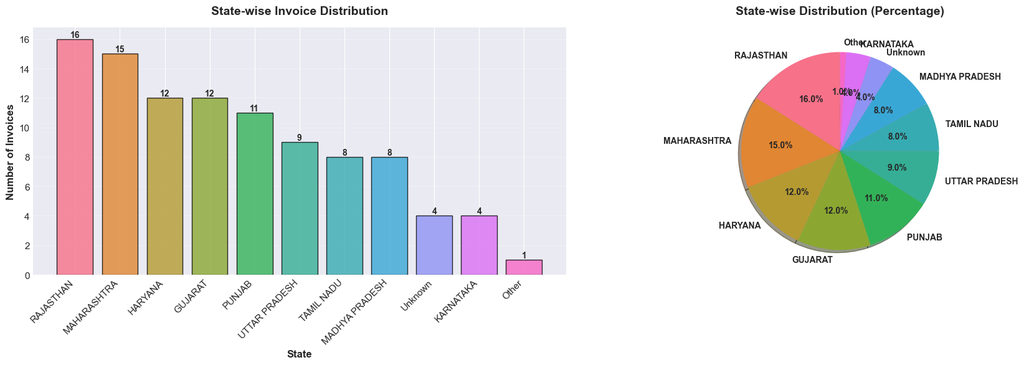

```
✓ Chart saved: state_distribution_eda.png
```

```python
fig, axes = plt.subplots(1, 2, figsize=(18, 6))

# State distribution bar chart
state_counts = df['state'].value_counts()
colors = sns.color_palette("husl", len(state_counts))
bars = axes[0].bar(range(len(state_counts)), state_counts.values, color=colors, edgecolor='black', alpha=0.8)
axes[0].set_xticks(range(len(state_counts)))
axes[0].set_xticklabels(state_counts.index, rotation=45, ha='right')
axes[0].set_xlabel('State', fontsize=12, fontweight='bold')
axes[0].set_ylabel('Number of Invoices', fontsize=12, fontweight='bold')
axes[0].set_title('State-wise Invoice Distribution', fontsize=14, fontweight='bold', pad=15)
axes[0].grid(axis='y', alpha=0.3)

# Add value labels
for bar in bars:
    height = bar.get_height()
    axes[0].text(bar.get_x() + bar.get_width()/2., height,
                f'{int(height)}',
                ha='center', va='bottom', fontsize=10, fontweight='bold')

# State distribution pie chart
axes[1].pie(state_counts.values, labels=state_counts.index, autopct='%1.1f%%',
           colors=colors, startangle=90, shadow=True,
           textprops={'fontsize': 10, 'fontweight': 'bold'})
axes[1].set_title('State-wise Distribution (Percentage)', fontsize=14, fontweight='bold', pad=15)

plt.tight_layout()
plt.savefig('state_distribution_eda.png', dpi=300, bbox_inches='tight')
plt.show()

print(f"✓ Chart saved: state_distribution_eda.png")
```

## 6. Language Analysis & Error Correlation

Analyzing the relationship between invoice language and extraction error rates.

```
================================================================================
LANGUAGE vs ERROR ANALYSIS
================================================================================
             Error Count  Error Rate  Avg Confidence  Std Confidence  \
language
English               53        0.64            0.82            0.10
Hindi/Mixed           10        0.77            0.75            0.06
Unknown                4        1.00            0.81            0.10

             Avg Fields Extracted
language
English                      3.65
Hindi/Mixed                  3.62
Unknown                      2.00
```

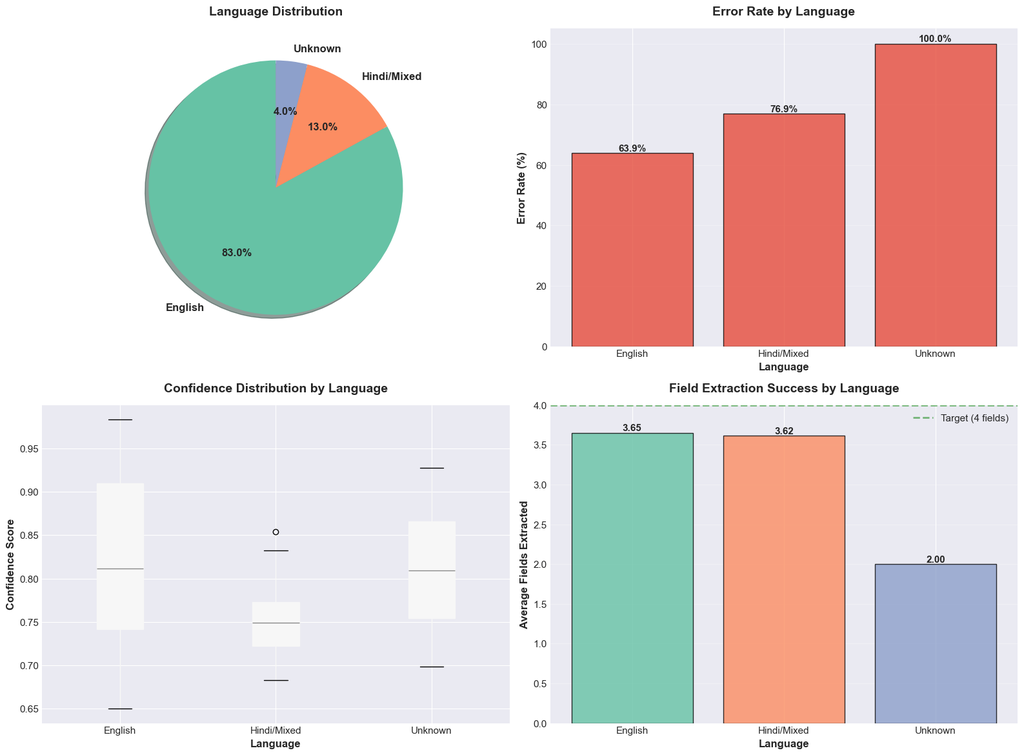

```
✓ Chart saved: language_analysis_eda.png
```

```python
# Calculate error rates by language
language_analysis = df.groupby('language').agg({
    'has_error': ['sum', 'mean'],
    'confidence': ['mean', 'std'],
    'fields_extracted': 'mean'
}).round(3)

language_analysis.columns = ['Error Count', 'Error Rate', 'Avg Confidence', 'Std Confidence', 'Avg Fields Extracted']
print("="*80)
print("LANGUAGE vs ERROR ANALYSIS")
print("="*80)
print(language_analysis)

# Visualization
fig, axes = plt.subplots(2, 2, figsize=(16, 12))

# Language distribution
lang_counts = df['language'].value_counts()
colors_lang = sns.color_palette("Set2", len(lang_counts))
axes[0, 0].pie(lang_counts.values, labels=lang_counts.index, autopct='%1.1f%%',
              colors=colors_lang, startangle=90, shadow=True,
              textprops={'fontsize': 12, 'fontweight': 'bold'})
axes[0, 0].set_title('Language Distribution', fontsize=14, fontweight='bold', pad=15)

# Error rate by language
error_rates = df.groupby('language')['has_error'].mean() * 100
bars = axes[0, 1].bar(error_rates.index, error_rates.values,
                     color=['#27ae60' if x < 15 else '#e74c3c' for x in error_rates.values],
                     edgecolor='black', alpha=0.8)
axes[0, 1].set_xlabel('Language', fontsize=12, fontweight='bold')
axes[0, 1].set_ylabel('Error Rate (%)', fontsize=12, fontweight='bold')
axes[0, 1].set_title('Error Rate by Language', fontsize=14, fontweight='bold', pad=15)
axes[0, 1].grid(axis='y', alpha=0.3)
for bar in bars:
    height = bar.get_height()
    axes[0, 1].text(bar.get_x() + bar.get_width()/2., height,
                   f'{height:.1f}%', ha='center', va='bottom', fontsize=11, fontweight='bold')

# Confidence by language
df.boxplot(column='confidence', by='language', ax=axes[1, 0], patch_artist=True)
axes[1, 0].set_xlabel('Language', fontsize=12, fontweight='bold')
axes[1, 0].set_ylabel('Confidence Score', fontsize=12, fontweight='bold')
axes[1, 0].set_title('Confidence Distribution by Language', fontsize=14, fontweight='bold', pad=15)
axes[1, 0].get_figure().suptitle('')

# Fields extracted by language
fields_by_lang = df.groupby('language')['fields_extracted'].mean()
bars = axes[1, 1].bar(fields_by_lang.index, fields_by_lang.values,
                     color=colors_lang, edgecolor='black', alpha=0.8)
axes[1, 1].set_xlabel('Language', fontsize=12, fontweight='bold')
axes[1, 1].set_ylabel('Average Fields Extracted', fontsize=12, fontweight='bold')
axes[1, 1].set_title('Field Extraction Success by Language', fontsize=14, fontweight='bold', pad=15)
axes[1, 1].set_ylim([0, 4])
axes[1, 1].axhline(y=4, color='green', linestyle='--', linewidth=2, alpha=0.5, label='Target (4 fields)')
axes[1, 1].grid(axis='y', alpha=0.3)
axes[1, 1].legend()
for bar in bars:
    height = bar.get_height()
    axes[1, 1].text(bar.get_x() + bar.get_width()/2., height,
                   f'{height:.2f}', ha='center', va='bottom', fontsize=11, fontweight='bold')

plt.tight_layout()
plt.savefig('language_analysis_eda.png', dpi=300, bbox_inches='tight')
plt.show()

print(f"\n✓ Chart saved: language_analysis_eda.png")
```

## 7. Processing Time Analysis

Comprehensive analysis of system performance and processing time distribution.

```
================================================================================
PROCESSING TIME STATISTICS
================================================================================
Mean:       25.72 seconds
Median:     25.71 seconds
Std Dev:    2.26 seconds
Min:        22.04 seconds
Max:        29.48 seconds
95th %ile:  29.25 seconds
99th %ile:  29.41 seconds

% Under 30s: 100.0%
```

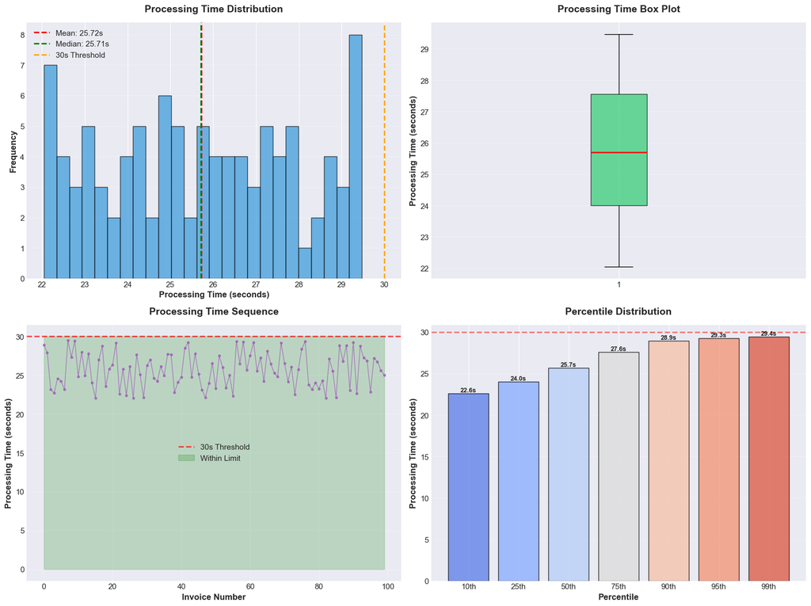

```
✓ Chart saved: processing_time_analysis_eda.png
```

```python
processing_times = df['processing_time'].dropna()

# Statistics
print("="*80)
print("PROCESSING TIME STATISTICS")
print("="*80)
print(f"Mean:       {processing_times.mean():.2f} seconds")
print(f"Median:     {processing_times.median():.2f} seconds")
print(f"Std Dev:    {processing_times.std():.2f} seconds")
print(f"Min:        {processing_times.min():.2f} seconds")
print(f"Max:        {processing_times.max():.2f} seconds")
print(f"95th %ile:  {processing_times.quantile(0.95):.2f} seconds")
print(f"99th %ile:  {processing_times.quantile(0.99):.2f} seconds")
print(f"\n% Under 30s: {(processing_times < 30).sum() / len(processing_times) * 100:.1f}%")

# Visualization
fig, axes = plt.subplots(2, 2, figsize=(16, 12))

# Histogram
axes[0, 0].hist(processing_times, bins=25, color='#3498db', alpha=0.7, edgecolor='black')
axes[0, 0].axvline(processing_times.mean(), color='red', linestyle='--', linewidth=2, label=f'Mean: {processing_times.mean():.2f}s')
axes[0, 0].axvline(processing_times.median(), color='green', linestyle='--', linewidth=2, label=f'Median: {processing_times.median():.2f}s')
axes[0, 0].axvline(30, color='orange', linestyle='--', linewidth=2, label='30s Threshold')
axes[0, 0].set_xlabel('Processing Time (seconds)', fontsize=12, fontweight='bold')
axes[0, 0].set_ylabel('Frequency', fontsize=12, fontweight='bold')
axes[0, 0].set_title('Processing Time Distribution', fontsize=14, fontweight='bold', pad=15)
axes[0, 0].legend()
axes[0, 0].grid(axis='y', alpha=0.3)

# Box plot
bp = axes[0, 1].boxplot(processing_times, vert=True, patch_artist=True,
                        boxprops=dict(facecolor='#2ecc71', alpha=0.7),
                        medianprops=dict(color='red', linewidth=2))
axes[0, 1].set_ylabel('Processing Time (seconds)', fontsize=12, fontweight='bold')
axes[0, 1].set_title('Processing Time Box Plot', fontsize=14, fontweight='bold', pad=15)
axes[0, 1].grid(axis='y', alpha=0.3)

# Time series
axes[1, 0].plot(range(len(processing_times)), processing_times.values,
               marker='o', linestyle='-', linewidth=1, markersize=3, color='#9b59b6', alpha=0.7)
axes[1, 0].axhline(30, color='red', linestyle='--', linewidth=2, label='30s Threshold', alpha=0.7)
axes[1, 0].fill_between(range(len(processing_times)), 0, 30, alpha=0.2, color='green', label='Within Limit')
axes[1, 0].set_xlabel('Invoice Number', fontsize=12, fontweight='bold')
axes[1, 0].set_ylabel('Processing Time (seconds)', fontsize=12, fontweight='bold')
axes[1, 0].set_title('Processing Time Sequence', fontsize=14, fontweight='bold', pad=15)
axes[1, 0].legend()
axes[1, 0].grid(alpha=0.3)

# Percentile analysis
percentiles = [10, 25, 50, 75, 90, 95, 99]
percentile_values = [processing_times.quantile(p/100) for p in percentiles]
colors_perc = sns.color_palette("coolwarm", len(percentiles))
bars = axes[1, 1].bar(range(len(percentiles)), percentile_values, color=colors_perc, edgecolor='black', alpha=0.8)
axes[1, 1].set_xticks(range(len(percentiles)))
axes[1, 1].set_xticklabels([f'{p}th' for p in percentiles])
axes[1, 1].set_xlabel('Percentile', fontsize=12, fontweight='bold')
axes[1, 1].set_ylabel('Processing Time (seconds)', fontsize=12, fontweight='bold')
axes[1, 1].set_title('Percentile Distribution', fontsize=14, fontweight='bold', pad=15)
axes[1, 1].axhline(30, color='red', linestyle='--', linewidth=2, alpha=0.5)
axes[1, 1].grid(axis='y', alpha=0.3)
for bar in bars:
    height = bar.get_height()
    axes[1, 1].text(bar.get_x() + bar.get_width()/2., height,
                   f'{height:.1f}s', ha='center', va='bottom', fontsize=9, fontweight='bold')

plt.tight_layout()
plt.savefig('processing_time_analysis_eda.png', dpi=300, bbox_inches='tight')
plt.show()

print(f"\n✓ Chart saved: processing_time_analysis_eda.png")
```